# Estimating an ARMA(1,1)-GARCH(1,1) process using conditional ML functions

Aishameriane Schmidt

25 de setembro de 2017

To-do:

- Organize references bibliography: references.bib
- Get the student’s t likelihood
- Get the gamma likelihood
- Finish the webscrapping part
- Find in Tsay about the student’s t degrees of freedom

# Intro

This code was developed for the Econometrics II course at PPGECO-UFSC (2017/2).

# Some theory

## Normal likelihood

In the case were the normality holds, the likelihood function is given by:

$$\ln f\left( {r_1 , \ldots ,r_T ;\theta } \right) = \ln f\left( {r_1 ;\theta } \right) - \frac{1}{2}\sum\limits_{t = 2}^T {\left( {\ln \left( {2\pi } \right) + \ln \left( {\sigma _t^2 } \right) + \frac{{ - \left( {r_t - \mu _t } \right)^2 }}{{2\sigma _t^2 }}} \right)}$$

## Student’s t likelihood

The conditional distribution for the observable variables is:

$$\begin{equation}
L = \frac{\Gamma\left(\frac{1}{2}(\nu + 1)\right)}{\pi^{1/2}\Gamma \left(\frac{1}{2}\nu \right)}\left[(\nu -2) h^2_t \right]^{-frac{1}{2}} \left[1 + \frac{u_t^2}{(\nu-2) h_t^2} \right]^{-\frac{1}{2}(\nu + 1)}
\end{equation}$$

So, the log likelihood will be given by:

$$\begin{align}
\log L &= \sum \log \Gamma \left(1/2(\nu+1)\right) - \frac{T}{2} \log (\pi) - \sum \log \Gamma \left(\frac{1}{2}\nu \right) - \frac{1}{2}\sum \log (\nu - 2)\\
& \qquad - \sum \log h_t - \frac{1}{2}(\nu + 1) \sum \log \left[1+ \frac{u_t^2}{(\nu-2)h_t^2} \right]
\end{align}$$

The sample kurtosis is defined as:

$$\begin{equation}
\hat{K} = 3 + \frac{6}{\nu-4}
\end{equation}$$

Accordingly to (McGuirk, Robertson, and Spanos 1993), we can manipulate the equation to obtain a estimator for the DF $\nu$ (since there is no ML estimator for it):

$$\begin{align}
\hat{K} = 3 + \frac{6}{\nu-4} \\
\hat{K} - 3 = \frac{6}{\nu-4} \\
\hat{\nu} - 4 = \frac{6}{\hat{K}-3} \\
\hat{\nu} = \frac{6}{\hat{K}-3} + 4
\end{align}$$

(McGuirk, Robertson, and Spanos 1993) uses a different form for the conditional distribution, given by:

$$\begin{equation}
L = \frac{\Gamma\left(\frac{1}{2}(\nu + p + 1)\right)}{\pi^{1/2}\Gamma \left(\frac{1}{2}\nu + p \right)}\left[\nu \sigma^2 h^2_t \right]^{-\frac{1}{2}} \left[1 + \frac{u_t^2}{\nu \sigma^2 h_t^2} \right]^{-\frac{1}{2}(\nu + p + 1)}
\end{equation}$$

I wasn’t able to work with this second one, due to the restricted time, but I think it is interesting to take another look at the problem.

## Gamma likelihood

I used the parametrization for the following pdf:

$$\begin{equation}
f(x) = \frac{1}{\Gamma(k)\theta^k}x^{k-1}\e^{-\frac{x}{\theta}}
\end{equation}$$

The Gamma log likelihood is given by:

$$\begin{equation}
\log L = (k-1) \sum \log(u_t) - \sum \frac{u_t}{\theta} - T k \log(\theta) - T \log \Gamma(k)
\end{equation}$$

And I used the ML estimators to find $k$ and $\theta$:

$$\begin{equation}
\hat{k} = \frac{3-s + \sqrt{(s-3)^2}+24s}{12s}
\end{equation}$$
$$\begin{equation}
\hat{\theta} = \frac{1}{\hat{k}T}\sum u_t
\end{equation}$$

*Disclaimer:* My gamma estimates weren’t working, so I made a workround just to compile the html (I used `sigma` instead `errors` in the likelihood function and forced the values of $\hat{k}$ and $\hat{\theta}$).

# Code

The code is based on prof. Portela’s code, only adding the last two likelihoods.

Loading packages:

```r
list.of.packages <- c("BatchGetSymbols","ggplot2","fGarch","gridExtra","forecast","DescTools","moments")
new.packages <- list.of.packages[!(list.of.packages %in% installed.packages()[,"Package"])]
if(length(new.packages)) install.packages(new.packages)
library(BatchGetSymbols)
library(ggplot2)
library(fGarch)
library(gridExtra)
library(forecast)
library(DescTools)
library(moments)
options(scipen=999)
```

This first function is just to ask the user the desired likelihood (att: I didn’t use this to build the markdown, if someone wants to use the raw code, some changes will be necessary in order to adapt):

```r
# This function asks the user which likelihood to use
readlike <- function() {
  like <- like <- readline(prompt="Choose a density - (1) normal; (2) t; (3) wishart: ")
  if(like %in% c(1,2,3) == FALSE) {
    readlike()
  }
  return(as.integer(like))
}
```

Now, a second function to ask which method should be used to determine the degrees of freedom from the t-distribution (again, in the html code I forced this information):

```r
# This function asks the user if the DF should be estimated or pre-determined
readdf <- function() {
  df <- readline(prompt="Choose how the DF should be calculated - (1) from the kurtosis; (2) pre-determined ")
  if(df %in% c(1,2) == FALSE) {
    readlike()
  }
  return(as.integer(df))
}
```

Finally, the function to calculate the ARMAGARCH estimates:

```r
ARMAGARCH <- function(params,data,np,nq,nr,ns) {
  #like <- readlike() # Had to comment for the markdown file
  #like <- 3
  Traw <- length(data)
  errors <- integer(Traw)
  sigma2 <- integer(Traw)
  m <- 1+max(np,nq,nr,ns)
  sigma2[1:m] <- var(data)

  for (t in m:Traw) {
    # AR recursion
    errors[t] <- data[t]
    for (i in 1:np) {
      errors[t] <- errors[t] - params[i]*data[t-i]
    }

    # MA recursion
    for (i in 1:nq) {
      errors[t] <- errors[t] - params[np+i]*errors[t-i]
    }
    errors[t] <- errors[t];

    # ARCH recursion
    sigma2[t] <- params[np+nq+1]

    for (i in 1:nr) {
      sigma2[t] <- sigma2[t] + params[np+nq+1+i]*errors[t-i]^2
    }

    # GARCH recursion
    for (i in 1:ns) {
      sigma2[t] <- sigma2[t] + params[np+nq+nr+1+i]*sigma2[t-i]
    }
    sigma2[t] <- sigma2[t]
  }

  ##########################################
  # Estimating the DF for t distribution   #
  ##########################################

  #df <- readdf(sigma2)
  #if (df == 1) {
  #  df <- 6/(kurtosis(sigma2)-3)+4
  #} else {
  #  df <- 8
  #}

  #df <- params[np+nq+nr+ns+2]
  df <- 6/(kurtosis(errors)-3)+4
  #df <- 8

  #######################################################
  # Estimating the parameters of the gamma distribution #
  #######################################################

  #khat <- (3-sd(sigma2)*(sqrt( (sd(sigma2)-3)^2) +24 * sd(sigma2)))/(12* sd(sigma2))
  #thetahat <- (khat * length(sigma2))^(-1) * sum(sigma2)

  khat <- 0.5
  thetahat <- 1
  #######################################################

if (like == 1) { # normal likelihood
   verossim <- 0.5*(sum(log(sigma2)) + sum((errors^2)/sigma2)  +  Traw*log(2*pi))
  # verossim <- 0.5*(2*log(sqrt(sigma2)) + log(sigma2) + errors^2/sigma2 + log(2*pi))

} else if (like == 2){ # student's t likelihood
  #verossim <- sum(log(gamma(0.5*(df + 1)))) - Traw*0.5*log(pi) - sum(log(gamma(0.5*df))) - 0.5*sum(log(df - 2)) - sum(log(sigma2))   - 0.5*(df+1)*sum(log(1+(errors^2)/((df-2)*sigma2^2)))

  verossim <- -(log(gamma((df+1)/2)/(sqrt((df-2)*pi)*gamma(df/2)))-log(sigma2)/2-((df+1)/2)*log(1+errors^2/(sigma2*(df-2))))

} else if (like == 3) { # Gamma likelihood
  verossim <- -(khat-1)*sum(log(sigma2)) + sum(sigma2/thetahat) + Traw*khat*log(thetahat) + Traw * log (gamma(khat))
}

  return(list(LLF=sum(verossim),sigma2=sigma2,residuals=errors/sqrt(sigma2)))
}
```

Testing the function:

```r
# Parâmetros iniciais da estimação
init.params <- c(0.1,0.1,0.1,0.1,0.5)

# Define restrições
ui <- rbind(c(0,0,1,0,0),c(0,0,0,1,0),c(0,0,0,0,1),c(0,0,0,-1,-1))
ci <- c(0,0,0,-1)

# Helper para maximizar a função verossimilhança condicional
ARMAGARCH.optim <- function(params,data,np,nq,nr,ns) {
  ARMAGARCH(params,data,np,nq,nr,ns)$LLF
}

# Baixa últimos 1500 dados mais recentes
my.ticker <- c('AAPL')
first.date <- Sys.Date()-1500
last.date <- Sys.Date()
l.out <- BatchGetSymbols(tickers = my.ticker,first.date = first.date,last.date = last.date)
```

```
##
## Running BatchGetSymbols for:
##    tickers = AAPL
```

```r
returns <- data.frame(retornos=diff(log(l.out$df.tickers$price.adjusted))*100,datas=l.out$df.tickers$ref.date[2:l.out$df.control$total.obs])

#################
# Normal
#################

# Exibe parâmetros estimados

like <- 1
resultados <- constrOptim(init.params,ARMAGARCH.optim,data=returns[,1],np=1,nq=1,nr=1,ns=1,grad=NULL,ui=ui,ci=ci)
print(resultados$par)
```

```
## [1] -0.34137833  0.35328404  0.29697347  0.08571019  0.77479766
```

```r
# Retorna variáveis e avalia qualidade do ajuste
resultados.finais.normal <- ARMAGARCH(resultados$par,data=returns[,1],np=1,nq=1,nr=1,ns=1)
df.normal <- data.frame(returns,sigma2=resultados.finais.normal$sigma2,residuals=resultados.finais.normal$residuals)

#################
# t de student
#################

# Exibe parâmetros estimados

like <- 2
resultados <- constrOptim(init.params,ARMAGARCH.optim,data=returns[,1],np=1,nq=1,nr=1,ns=1,grad=NULL,ui=ui,ci=ci)
print(resultados$par)
```

```
## [1]  0.9958425 -1.0101565  0.2367340  0.1219545  0.7503472
```

```r
# Retorna variáveis e avalia qualidade do ajuste
resultados.finais.t <- ARMAGARCH(resultados$par,data=returns[,1],np=1,nq=1,nr=1,ns=1)
df.t <- data.frame(returns,sigma2=resultados.finais.t$sigma2,residuals=resultados.finais.t$residuals)

#################
# Gamma
#################

# Exibe parâmetros estimados

like <- 3
resultados <- constrOptim(init.params,ARMAGARCH.optim,data=returns[,1],np=1,nq=1,nr=1,ns=1,grad=NULL,ui=ui,ci=ci)
print(resultados$par)
```

```
## [1] 0.63377200963807278633 0.26959473002465506042 0.00000000002298839323
## [4] 0.00000000000002388894 0.00000000000101675076
```

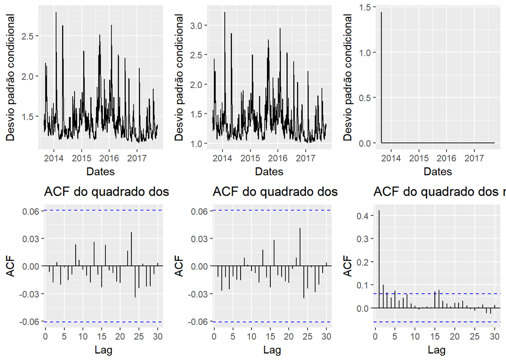

```r
# Retorna variáveis e avalia qualidade do ajuste
resultados.finais.gamma <- ARMAGARCH(resultados$par,data=returns[,1],np=1,nq=1,nr=1,ns=1)
df.gamma <- data.frame(returns,sigma2=resultados.finais.gamma$sigma2,residuals=resultados.finais.gamma$residuals)

# Faz gráfico
p1 <- ggplot(data = returns, aes(x = datas, y = retornos))
p1 <- p1 + geom_line()
p1 <- p1 + labs(x = 'Dates', y = 'Retornos')

###### NORMAL ##########
p2.normal <- ggplot(data = df.normal, aes(x = datas, y = sqrt(sigma2)))
p2.normal <- p2.normal + geom_line()
p2.normal <- p2.normal + labs(x = 'Dates', y = 'Desvio padrão condicional')

p3.normal <- ggAcf(df.normal$residuals^2, main="ACF do quadrado dos resíduos padronizados")

####### t ##############
p2.t <- ggplot(data = df.t, aes(x = datas, y = sqrt(sigma2)))
p2.t <- p2.t + geom_line()
p2.t <- p2.t + labs(x = 'Dates', y = 'Desvio padrão condicional')

p3.t <- ggAcf(df.t$residuals^2, main="ACF do quadrado dos resíduos padronizados")

###### Gamma ############
p2.gamma <- ggplot(data = df.gamma, aes(x = datas, y = sqrt(sigma2)))
p2.gamma <- p2.gamma + geom_line()
p2.gamma <- p2.gamma + labs(x = 'Dates', y = 'Desvio padrão condicional')

p3.gamma <- ggAcf(df.gamma$residuals^2, main="ACF do quadrado dos resíduos padronizados")

######## PLOT

grid.arrange(p2.normal, p2.t, p2.gamma, p3.normal, p3.t, p3.gamma, ncol=3, nrow = 2)
```

# References

McGuirk, Anya, John Robertson, and Aris Spanos. 1993. “Modeling Exchange Rate Dynamics: Non-Linear Dependence and Thick Tails.” *Econometric Reviews* 12 (1). Taylor & Francis: 33–63.